# Final Project

## Guiding question: Are cat owners or dog owners more likely to be depressed and/or use illicit drugs?

This is a very interesting research question because there are many studies that show owning a pet leads to their owners living a healthier lifestyle, but I was unable to find any research on how the *type* of pet you own may affect your mental health or illicit drug use.

#### Dataset sources:

Pet Ownership dataset: https://data.world/datanerd/cat-vs-dog-popularity-in-u-s Depression/Marijuana Use dataset: https://www.samhsa.gov/data/report/2017-2018-nsduh-state-prevalence-estimates Average age source: https://en.wikipedia.org/wiki/List_of_U.S._states_and_territories_by_median_age

```r
library(plyr)
library(rvest)
library(mosaic)
library(DataComputing)
library(tidyverse)
library(tidyr)
library(dplyr)
library("httr")
library("readxl")
library(readr)
```

### Read in and Inspect Datasets

I began my project by reading in the datasets.

### Depression and Pet Ownership

After reading in the datasets, I got them in glyph-ready form.

```r
# Renaming and adding a few variables
petOwnership <-
petOwnership %>%
  rename(dogPercent = `Percentage of Dog Owners`, catPercent = `Percentage of Cat Owners`) %>%
  mutate(difference = dogPercent - catPercent)
petOwnership %>%
  head(10)
```

| Location | Number of Households (in 1000) | Percentage of households with pets | Number of Pet Households (in 1000) | dogPercent | Dog Owning Households (1000s) | Mean Number of Dogs per household | Dog Population (in 1000) | catPercent | Cat Owning Households | Mean Number of Cats | Cat Population | difference |
| --- | --- | --- | --- | --- | --- | --- | --- | --- | --- | --- | --- | --- |
| Alabama | 1828 | 59.5 | 1088 | 44.1 | 807 | 1.7 | 1410 | 27.4 | 501 | 2.5 | 1252 | 16.7 |
| Arizona | 2515 | 59.5 | 1497 | 40.1 | 1008 | 1.8 | 1798 | 29.6 | 743 | 1.9 | 1438 | 10.5 |
| Arkansas | 1148 | 62.4 | 716 | 47.9 | 550 | 2.0 | 1097 | 30.6 | 351 | 2.3 | 810 | 17.3 |
| California | 12974 | 52.9 | 6865 | 32.8 | 4260 | 1.6 | 6687 | 28.3 | 3687 | 1.9 | 7118 | 4.5 |
| Colorado | 1986 | 61.3 | 1217 | 42.5 | 845 | 1.6 | 1349 | 32.3 | 642 | 1.9 | 1191 | 10.2 |
| Connecticut | 1337 | 54.4 | 728 | 28.3 | 379 | 1.3 | 507 | 31.9 | 427 | 1.9 | 796 | -3.6 |
| Delaware | 334 | 56.6 | 189 | 33.7 | 113 | 1.4 | 163 | 33.7 | 113 | 1.7 | 187 | 0.0 |
| District of Columbia | 287 | 21.9 | 63 | 13.1 | 38 | 1.1 | 42 | 11.6 | 33 | 1.9 | 63 | 1.5 |
| Florida | 7609 | 54.4 | 4138 | 35.7 | 2718 | 1.5 | 4210 | 27.3 | 2079 | 2.1 | 4375 | 8.4 |
| Georgia | 3798 | 55.1 | 2093 | 40.1 | 1522 | 1.6 | 2479 | 27.3 | 1037 | 2.1 | 2162 | 12.8 |

```r
depression <-
  depression %>%
    rename(totalDepression = '18 or Older Estimate')
depression %>%
  head(10)
```

| Order | State | totalDepression | 18 or Older 95% CI (Lower) | 18 or Older 95% CI (Upper) | 18-25 Estimate | 18-25 95% CI (Lower) | 18-25 95% CI (Upper) | 26 or Older Estimate | 26 or Older 95% CI (Lower) | 26 or Older 95% CI (Upper) |
| --- | --- | --- | --- | --- | --- | --- | --- | --- | --- | --- |
| 1 | Total U.S. | 19.00% | 18.63% | 19.38% | 26.04% | 25.41% | 26.67% | 17.88% | 17.47% | 18.30% |
| 2 | Northeast | 18.53% | 17.83% | 19.26% | 26.47% | 25.33% | 27.64% | 17.30% | 16.50% | 18.12% |
| 3 | Midwest | 19.88% | 19.26% | 20.51% | 27.47% | 26.46% | 28.51% | 18.63% | 17.94% | 19.35% |
| 4 | South | 18.18% | 17.63% | 18.74% | 24.11% | 23.26% | 24.99% | 17.24% | 16.62% | 17.87% |
| 5 | West | 19.90% | 19.16% | 20.67% | 27.44% | 26.23% | 28.68% | 18.68% | 17.86% | 19.54% |
| 6 | Alabama | 21.39% | 19.15% | 23.81% | 24.24% | 21.37% | 27.36% | 20.93% | 18.43% | 23.68% |
| 7 | Alaska | 20.50% | 18.51% | 22.65% | 28.47% | 25.19% | 31.99% | 19.22% | 17.00% | 21.65% |
| 8 | Arizona | 19.24% | 17.00% | 21.71% | 24.56% | 21.42% | 27.99% | 18.37% | 15.88% | 21.17% |
| 9 | Arkansas | 20.27% | 18.26% | 22.45% | 25.64% | 22.66% | 28.86% | 19.40% | 17.15% | 21.86% |
| 10 | California | 18.54% | 17.44% | 19.69% | 26.53% | 24.66% | 28.48% | 17.22% | 16.00% | 18.52% |

```r
stateAges <-
  stateAges %>%
  rename(medianAge = "Median age in years")
stateAges %>%
  head(10)
```

| State | medianAge |
| --- | --- |
| Maine, | 44.9 |
| New Hampshire | 43.0 |
| Vermont | 42.8 |
| West Virginia | 42.7 |
| Florida | 42.2 |
| Connecticut | 41.0 |
| Pennsylvania | 40.8 |
| Delaware | 40.7 |
| Rhode Island | 40.1 |
| New Jersey | 40.0 |

Next, I created my first visualization. The “difference” variable will be used a lot throughout this project - it is the difference in the percent of dog owners and the percent of cat owners. Therefore, a positive difference means there are more dog owners than cat owners, and a negative difference means there are more cat owners than dog owners. This graph illustrates which states are more of “cat states”, and which states are “dog states”.

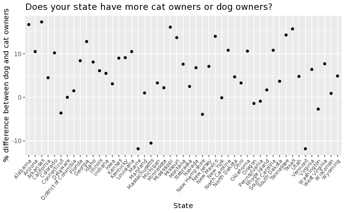

```r
# Introductory visualization
petOwnership %>%
  ggplot(aes(x = Location, y = difference)) + geom_point() + theme(axis.text.x = element_text(angle = 50, hjust=1, size = 8)) + xlab("State") + ylab("% difference between dog and cat owners") + ggtitle("Does your state have more cat owners or dog owners?")
```

Next, I combined the pet dataset and depression dataset

```r
joinedDepression <-
petOwnership %>%
  full_join(depression, by = c("Location" = "State" )) %>%
  mutate(difference = dogPercent - catPercent) %>%
  mutate(totalDepression = gsub(pattern = "[%]$", replacement = "", totalDepression)) %>%
  mutate(totalDepression = as.numeric(totalDepression)) %>%
  rename(petPercent = 'Percentage of households with pets') %>%
  select(Location, difference, petPercent, totalDepression)
joinedDepression %>%
  head(10)
```

| Location | difference | petPercent | totalDepression |
| --- | --- | --- | --- |
| Alabama | 16.7 | 59.5 | 21.39 |
| Arizona | 10.5 | 59.5 | 19.24 |
| Arkansas | 17.3 | 62.4 | 20.27 |
| California | 4.5 | 52.9 | 18.54 |
| Colorado | 10.2 | 61.3 | 21.50 |
| Connecticut | -3.6 | 54.4 | 19.03 |
| Delaware | 0.0 | 56.6 | 20.03 |
| District of Columbia | 1.5 | 21.9 | 22.21 |
| Florida | 8.4 | 54.4 | 17.39 |
| Georgia | 12.8 | 55.1 | 18.09 |

In order to analyze parts of the country as a whole, I created a region variable.

```r
joinedDepression <-
joinedDepression %>%
  mutate(region = ifelse(Location %in% c("Washington", "Oregon", "Idaho", "Montana", "Wyoming", "California", "Nevada", "Utah", "Arizona", "New Mexico", "Colorado"), "West",
                    ifelse(Location %in% c("Texas", "Oaklahoma", "Arkansas", "Louisiana", "Mississippi", "Alabama", "Georgia", "Florida", "South Carolina", "North Carolina", "Tennessee", "Kentucky", "Virginia", "West Virginia", "Delaware", "District of Colombia"), "South",
                    ifelse(Location %in% c("Minnesota", "North Dakota", "South Dakota", "Iowa", "Nebraska", "Wisconsin", "Missouri", "Indiana", "Illinois", "Michigan", "Ohio", "Kansas"), "Midwest", "Northeast"))))
joinedDepression %>%
  head(10)
```

| Location | difference | petPercent | totalDepression | region |
| --- | --- | --- | --- | --- |
| Alabama | 16.7 | 59.5 | 21.39 | South |
| Arizona | 10.5 | 59.5 | 19.24 | West |
| Arkansas | 17.3 | 62.4 | 20.27 | South |
| California | 4.5 | 52.9 | 18.54 | West |
| Colorado | 10.2 | 61.3 | 21.50 | West |
| Connecticut | -3.6 | 54.4 | 19.03 | Northeast |
| Delaware | 0.0 | 56.6 | 20.03 | South |
| District of Columbia | 1.5 | 21.9 | 22.21 | Northeast |
| Florida | 8.4 | 54.4 | 17.39 | South |
| Georgia | 12.8 | 55.1 | 18.09 | South |

Using the joined datasets, I made a graph illustrating the relationship between mental illness, the “difference” variable, and region.

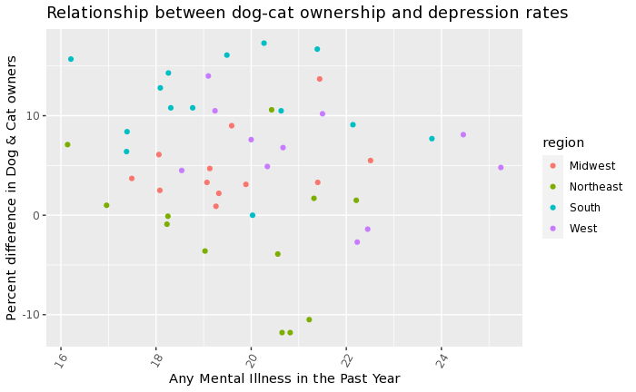

```r
joinedDepression %>%
  ggplot(aes(x = totalDepression, y = difference, color = region)) + geom_point() + theme(axis.text.x = element_text(angle = 60, hjust=1)) + xlab("Any Mental Illness in the Past Year") + ylab("Percent difference in Dog & Cat owners") +ggtitle("Relationship between dog-cat ownership and depression rates")
```

I then mapped depression by state. totalDepression is the percentage of citizens in a state who had any mental illness in the past year. Texas, for example, has very low depression rates, and Utah appears to be the highest. This this makes sense as it is consistent with my findings on dog ownership because there does not appear to be a pattern.

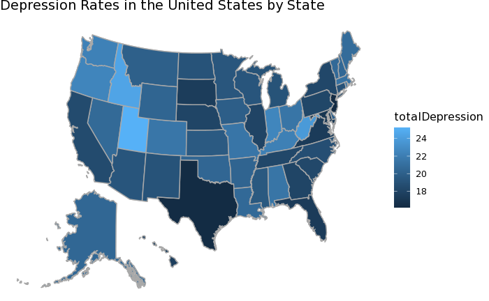

```r
joinedDepression %>%
  filter(region %in% c("Northeast", "South", "Midwest", "West")) %>%
  USMap(key = "Location", fill = totalDepression) + ggtitle("Depression Rates in the United States by State")
```

I also wanted to see the depression rates for regions as a whole, so I grouped by region.

```r
depressionByRegion <-
joinedDepression %>%
  group_by(region) %>%
  summarise(regionPercent = mean(totalDepression, na.rm = TRUE)) %>%
  arrange(desc(regionPercent))
depressionByRegion %>%
  head(4)
```

| region | regionPercent |
| --- | --- |
| West | 21.25273 |
| Midwest | 19.60333 |
| Northeast | 19.44158 |
| South | 19.44000 |

I then created a graph to illustrate the regions and their respective mental illness rates.

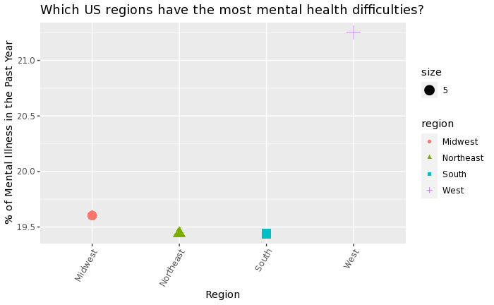

```r
depressionByRegion %>%
  ggplot(aes(x = region, y = regionPercent, shape = region, size = 5, color = region)) + geom_point() + theme(axis.text.x = element_text(angle = 60, hjust=1)) + ggtitle("Which US regions have the most mental health difficulties?") + xlab("Region") + ylab("% of Mental Illness in the Past Year")
```

```r
joinedDepression %>%
  select(Location, totalDepression) %>%
  summarise(minDep = min(totalDepression))
```

| minDep |
| --- |
| 16.14 |

```r
joinedDepression %>%
  select(Location, totalDepression) %>%
  summarise(maxDep = max(totalDepression))
```

| maxDep |
| --- |
| 25.25 |

Lastly, I was curious on whether there was a relationship between pet ownership in general (not just dogs or cats) and depression, so I created a graph on this relationship.

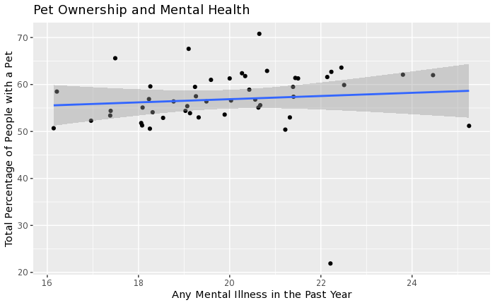

```r
joinedDepression %>%
  ggplot(aes(x = totalDepression, y = petPercent)) + geom_point() + geom_smooth(method = 'lm') + ylab("Total Percentage of People with a Pet") + xlab("Any Mental Illness in the Past Year")+ ggtitle("Pet Ownership and Mental Health")
```

### Marijuana use in the past year and pet ownership

Moving on to the illicit drugs portion of the question, I will the relationship between marijuana use and pet ownership. I have to again clean the data, join the petOwnership dataset with the marijuana dataset, and create a region variable.

```r
# Rnaming a variable in the marijuana dataset for simplicity
marijuana <-
  marijuana %>%
    rename(totalMarijuana = '18 or Older Estimate')
marijuana %>%
  head(10)
```

| Order | State | 12 or Older Estimate | 12 or Older 95% CI (Lower) | 12 or Older 95% CI (Upper) | 12-17 Estimate | 12-17 95% CI (Lower) | 12-17 95% CI (Upper) | 18-25 Estimate | 18-25 95% CI (Lower) | 18-25 95% CI (Upper) | 26 or Older Estimate | 26 or Older 95% CI (Lower) | 26 or Older 95% CI (Upper) | totalMarijuana | 18 or Older 95% CI (Lower) | 18 or Older 95% CI (Upper) |
| --- | --- | --- | --- | --- | --- | --- | --- | --- | --- | --- | --- | --- | --- | --- | --- | --- |
| 1 | Total U.S. | 15.47% | 15.13% | 15.81% | 12.45% | 11.99% | 12.92% | 34.80% | 34.04% | 35.57% | 12.73% | 12.36% | 13.11% | 15.77% | 15.41% | 16.14% |
| 2 | Northeast | 15.97% | 15.35% | 16.60% | 13.00% | 12.16% | 13.89% | 38.99% | 37.52% | 40.49% | 12.69% | 11.96% | 13.44% | 16.24% | 15.58% | 16.92% |
| 3 | Midwest | 14.99% | 14.46% | 15.54% | 12.58% | 11.85% | 13.36% | 34.75% | 33.59% | 35.93% | 12.05% | 11.42% | 12.71% | 15.24% | 14.66% | 15.83% |
| 4 | South | 12.92% | 12.51% | 13.35% | 11.20% | 10.56% | 11.87% | 30.14% | 29.17% | 31.13% | 10.40% | 9.89% | 10.93% | 13.10% | 12.65% | 13.56% |
| 5 | West | 19.57% | 18.92% | 20.23% | 13.96% | 13.05% | 14.92% | 39.08% | 37.64% | 40.54% | 17.07% | 16.28% | 17.88% | 20.14% | 19.43% | 20.86% |
| 6 | Alabama | 12.59% | 10.99% | 14.37% | 10.24% | 8.29% | 12.58% | 27.09% | 23.68% | 30.79% | 10.55% | 8.81% | 12.58% | 12.82% | 11.13% | 14.73% |
| 7 | Alaska | 23.72% | 21.48% | 26.11% | 16.42% | 13.82% | 19.40% | 39.30% | 35.15% | 43.61% | 22.14% | 19.52% | 24.99% | 24.52% | 22.10% | 27.12% |
| 8 | Arizona | 16.71% | 14.64% | 19.00% | 11.97% | 9.70% | 14.67% | 32.34% | 28.37% | 36.58% | 14.72% | 12.44% | 17.33% | 17.20% | 15.00% | 19.65% |
| 9 | Arkansas | 13.40% | 11.79% | 15.19% | 11.38% | 9.44% | 13.65% | 26.85% | 23.30% | 30.73% | 11.46% | 9.70% | 13.50% | 13.61% | 11.89% | 15.53% |
| 10 | California | 18.43% | 17.49% | 19.40% | 13.82% | 12.45% | 15.32% | 39.23% | 37.02% | 41.48% | 15.54% | 14.45% | 16.70% | 18.89% | 17.88% | 19.95% |

```r
joinedMarijuana <-
petOwnership %>%
  full_join(marijuana, by = c("Location" = "State" )) %>%
  mutate(difference = dogPercent - catPercent) %>%
  mutate(totalMarijuana = gsub(pattern = "[%]$", replacement = "", totalMarijuana)) %>%
  mutate(totalMarijuana = as.numeric(totalMarijuana))
joinedMarijuana %>%
  head(10)
```

| Location | Number of Households (in 1000) | Percentage of households with pets | Number of Pet Households (in 1000) | dogPercent | Dog Owning Households (1000s) | Mean Number of Dogs per household | Dog Population (in 1000) | catPercent | Cat Owning Households | Mean Number of Cats | Cat Population | difference | Order | 12 or Older Estimate | 12 or Older 95% CI (Lower) | 12 or Older 95% CI (Upper) | 12-17 Estimate | 12-17 95% CI (Lower) | 12-17 95% CI (Upper) | 18-25 Estimate | 18-25 95% CI (Lower) | 18-25 95% CI (Upper) | 26 or Older Estimate | 26 or Older 95% CI (Lower) | 26 or Older 95% CI (Upper) | totalMarijuana | 18 or Older 95% CI (Lower) | 18 or Older 95% CI (Upper) |
| --- | --- | --- | --- | --- | --- | --- | --- | --- | --- | --- | --- | --- | --- | --- | --- | --- | --- | --- | --- | --- | --- | --- | --- | --- | --- | --- | --- | --- |
| Alabama | 1828 | 59.5 | 1088 | 44.1 | 807 | 1.7 | 1410 | 27.4 | 501 | 2.5 | 1252 | 16.7 | 6 | 12.59% | 10.99% | 14.37% | 10.24% | 8.29% | 12.58% | 27.09% | 23.68% | 30.79% | 10.55% | 8.81% | 12.58% | 12.82 | 11.13% | 14.73% |
| Arizona | 2515 | 59.5 | 1497 | 40.1 | 1008 | 1.8 | 1798 | 29.6 | 743 | 1.9 | 1438 | 10.5 | 8 | 16.71% | 14.64% | 19.00% | 11.97% | 9.70% | 14.67% | 32.34% | 28.37% | 36.58% | 14.72% | 12.44% | 17.33% | 17.20 | 15.00% | 19.65% |
| Arkansas | 1148 | 62.4 | 716 | 47.9 | 550 | 2.0 | 1097 | 30.6 | 351 | 2.3 | 810 | 17.3 | 9 | 13.40% | 11.79% | 15.19% | 11.38% | 9.44% | 13.65% | 26.85% | 23.30% | 30.73% | 11.46% | 9.70% | 13.50% | 13.61 | 11.89% | 15.53% |
| California | 12974 | 52.9 | 6865 | 32.8 | 4260 | 1.6 | 6687 | 28.3 | 3687 | 1.9 | 7118 | 4.5 | 10 | 18.43% | 17.49% | 19.40% | 13.82% | 12.45% | 15.32% | 39.23% | 37.02% | 41.48% | 15.54% | 14.45% | 16.70% | 18.89 | 17.88% | 19.95% |
| Colorado | 1986 | 61.3 | 1217 | 42.5 | 845 | 1.6 | 1349 | 32.3 | 642 | 1.9 | 1191 | 10.2 | 11 | 26.78% | 24.38% | 29.33% | 16.93% | 13.99% | 20.33% | 49.23% | 45.00% | 53.48% | 24.37% | 21.60% | 27.37% | 27.77 | 25.21% | 30.49% |
| Connecticut | 1337 | 54.4 | 728 | 28.3 | 379 | 1.3 | 507 | 31.9 | 427 | 1.9 | 796 | -3.6 | 12 | 18.45% | 16.54% | 20.53% | 16.09% | 13.44% | 19.13% | 46.38% | 42.02% | 50.81% | 14.22% | 12.10% | 16.62% | 18.68 | 16.66% | 20.89% |
| Delaware | 334 | 56.6 | 189 | 33.7 | 113 | 1.4 | 163 | 33.7 | 113 | 1.7 | 187 | 0.0 | 13 | 17.11% | 15.25% | 19.15% | 14.03% | 11.65% | 16.81% | 41.09% | 36.82% | 45.51% | 13.97% | 11.93% | 16.28% | 17.40 | 15.43% | 19.56% |
| District of Columbia | 287 | 21.9 | 63 | 13.1 | 38 | 1.1 | 42 | 11.6 | 33 | 1.9 | 63 | 1.5 | 14 | 26.47% | 23.94% | 29.16% | 16.41% | 13.67% | 19.57% | 51.93% | 46.82% | 57.00% | 22.44% | 19.62% | 25.54% | 27.03 | 24.40% | 29.84% |
| Florida | 7609 | 54.4 | 4138 | 35.7 | 2718 | 1.5 | 4210 | 27.3 | 2079 | 2.1 | 4375 | 8.4 | 15 | 14.34% | 13.30% | 15.44% | 13.01% | 11.59% | 14.57% | 34.58% | 32.29% | 36.95% | 11.75% | 10.58% | 13.03% | 14.45 | 13.35% | 15.63% |
| Georgia | 3798 | 55.1 | 2093 | 40.1 | 1522 | 1.6 | 2479 | 27.3 | 1037 | 2.1 | 2162 | 12.8 | 16 | 13.50% | 12.20% | 14.92% | 11.61% | 9.77% | 13.75% | 30.91% | 27.82% | 34.18% | 10.86% | 9.40% | 12.53% | 13.71 | 12.32% | 15.24% |

```r
joinedMarijuana <-
joinedMarijuana %>%
  mutate(region = ifelse(Location %in% c("Washington", "Oregon", "Idaho", "Montana", "Wyoming", "California", "Nevada", "Utah", "Arizona", "New Mexico", "Colorado"), "West",
                    ifelse(Location %in% c("Texas", "Oaklahoma", "Arkansas", "Louisiana", "Mississippi", "Alabama", "Georgia", "Florida", "South Carolina", "North Carolina", "Tennessee", "Kentucky", "Virginia", "West Virginia", "Delaware", "District of Colombia"), "South",
                    ifelse(Location %in% c("Minnesota", "North Dakota", "South Dakota", "Iowa", "Nebraska", "Wisconsin", "Missouri", "Indiana", "Illinois", "Michigan", "Ohio", "Kansas"), "Midwest", "Northeast"))))
joinedMarijuana %>%
  head(10)
```

| Location | Number of Households (in 1000) | Percentage of households with pets | Number of Pet Households (in 1000) | dogPercent | Dog Owning Households (1000s) | Mean Number of Dogs per household | Dog Population (in 1000) | catPercent | Cat Owning Households | Mean Number of Cats | Cat Population | difference | Order | 12 or Older Estimate | 12 or Older 95% CI (Lower) | 12 or Older 95% CI (Upper) | 12-17 Estimate | 12-17 95% CI (Lower) | 12-17 95% CI (Upper) | 18-25 Estimate | 18-25 95% CI (Lower) | 18-25 95% CI (Upper) | 26 or Older Estimate | 26 or Older 95% CI (Lower) | 26 or Older 95% CI (Upper) | totalMarijuana | 18 or Older 95% CI (Lower) | 18 or Older 95% CI (Upper) | region |
| --- | --- | --- | --- | --- | --- | --- | --- | --- | --- | --- | --- | --- | --- | --- | --- | --- | --- | --- | --- | --- | --- | --- | --- | --- | --- | --- | --- | --- | --- |
| Alabama | 1828 | 59.5 | 1088 | 44.1 | 807 | 1.7 | 1410 | 27.4 | 501 | 2.5 | 1252 | 16.7 | 6 | 12.59% | 10.99% | 14.37% | 10.24% | 8.29% | 12.58% | 27.09% | 23.68% | 30.79% | 10.55% | 8.81% | 12.58% | 12.82 | 11.13% | 14.73% | South |
| Arizona | 2515 | 59.5 | 1497 | 40.1 | 1008 | 1.8 | 1798 | 29.6 | 743 | 1.9 | 1438 | 10.5 | 8 | 16.71% | 14.64% | 19.00% | 11.97% | 9.70% | 14.67% | 32.34% | 28.37% | 36.58% | 14.72% | 12.44% | 17.33% | 17.20 | 15.00% | 19.65% | West |
| Arkansas | 1148 | 62.4 | 716 | 47.9 | 550 | 2.0 | 1097 | 30.6 | 351 | 2.3 | 810 | 17.3 | 9 | 13.40% | 11.79% | 15.19% | 11.38% | 9.44% | 13.65% | 26.85% | 23.30% | 30.73% | 11.46% | 9.70% | 13.50% | 13.61 | 11.89% | 15.53% | South |
| California | 12974 | 52.9 | 6865 | 32.8 | 4260 | 1.6 | 6687 | 28.3 | 3687 | 1.9 | 7118 | 4.5 | 10 | 18.43% | 17.49% | 19.40% | 13.82% | 12.45% | 15.32% | 39.23% | 37.02% | 41.48% | 15.54% | 14.45% | 16.70% | 18.89 | 17.88% | 19.95% | West |
| Colorado | 1986 | 61.3 | 1217 | 42.5 | 845 | 1.6 | 1349 | 32.3 | 642 | 1.9 | 1191 | 10.2 | 11 | 26.78% | 24.38% | 29.33% | 16.93% | 13.99% | 20.33% | 49.23% | 45.00% | 53.48% | 24.37% | 21.60% | 27.37% | 27.77 | 25.21% | 30.49% | West |
| Connecticut | 1337 | 54.4 | 728 | 28.3 | 379 | 1.3 | 507 | 31.9 | 427 | 1.9 | 796 | -3.6 | 12 | 18.45% | 16.54% | 20.53% | 16.09% | 13.44% | 19.13% | 46.38% | 42.02% | 50.81% | 14.22% | 12.10% | 16.62% | 18.68 | 16.66% | 20.89% | Northeast |
| Delaware | 334 | 56.6 | 189 | 33.7 | 113 | 1.4 | 163 | 33.7 | 113 | 1.7 | 187 | 0.0 | 13 | 17.11% | 15.25% | 19.15% | 14.03% | 11.65% | 16.81% | 41.09% | 36.82% | 45.51% | 13.97% | 11.93% | 16.28% | 17.40 | 15.43% | 19.56% | South |
| District of Columbia | 287 | 21.9 | 63 | 13.1 | 38 | 1.1 | 42 | 11.6 | 33 | 1.9 | 63 | 1.5 | 14 | 26.47% | 23.94% | 29.16% | 16.41% | 13.67% | 19.57% | 51.93% | 46.82% | 57.00% | 22.44% | 19.62% | 25.54% | 27.03 | 24.40% | 29.84% | Northeast |
| Florida | 7609 | 54.4 | 4138 | 35.7 | 2718 | 1.5 | 4210 | 27.3 | 2079 | 2.1 | 4375 | 8.4 | 15 | 14.34% | 13.30% | 15.44% | 13.01% | 11.59% | 14.57% | 34.58% | 32.29% | 36.95% | 11.75% | 10.58% | 13.03% | 14.45 | 13.35% | 15.63% | South |
| Georgia | 3798 | 55.1 | 2093 | 40.1 | 1522 | 1.6 | 2479 | 27.3 | 1037 | 2.1 | 2162 | 12.8 | 16 | 13.50% | 12.20% | 14.92% | 11.61% | 9.77% | 13.75% | 30.91% | 27.82% | 34.18% | 10.86% | 9.40% | 12.53% | 13.71 | 12.32% | 15.24% | South |

With this joined dataset, joinedMarijuana, I created a graph mapping the relationship between marijuana use and whether someone is a cat owner or dog owner. As a reminder, the higher the difference variable, the more of a “dog state” it is!

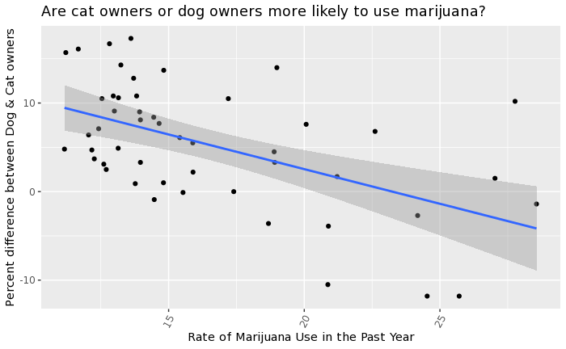

```r
joinedMarijuana %>%
  ggplot(aes(x = totalMarijuana, y = difference)) + geom_point() + geom_smooth(method='lm') + theme(axis.text.x = element_text(angle = 60, hjust=1)) + xlab("Rate of Marijuana Use in the Past Year") + ylab("Percent difference between Dog & Cat owners") + ggtitle("Are cat owners or dog owners more likely to use marijuana?")
```

### Does age play a factor into depression or pet ownership?

Lastly, I wanted to see if age played a factor in depression rates. I imported an excel spreadsheet with the median age in each state and joined it with the depression dataset.

```r
# Joining the median age dataset with the depression dataset
ageDepression <-
  stateAges %>%
  left_join(depression, by = c("State" = "State")) %>%
  mutate(totalDepression = gsub(pattern = "[%]$", replacement = "", totalDepression)) %>%
  mutate(totalDepression = as.numeric(totalDepression))
ageDepression %>%
  head(10)
```

| State | medianAge | Order | totalDepression | 18 or Older 95% CI (Lower) | 18 or Older 95% CI (Upper) | 18-25 Estimate | 18-25 95% CI (Lower) | 18-25 95% CI (Upper) | 26 or Older Estimate | 26 or Older 95% CI (Lower) | 26 or Older 95% CI (Upper) |
| --- | --- | --- | --- | --- | --- | --- | --- | --- | --- | --- | --- |
| Maine, | 44.9 | NA | NA | NA | NA | NA | NA | NA | NA | NA | NA |
| New Hampshire | 43.0 | 35 | 20.56 | 18.36% | 22.96% | 28.85% | 25.25% | 32.73% | 19.30% | 16.90% | 21.95% |
| Vermont | 42.8 | 51 | 20.65 | 18.56% | 22.91% | 29.59% | 26.21% | 33.20% | 19.10% | 16.79% | 21.66% |
| West Virginia | 42.7 | 54 | 23.80 | 21.47% | 26.29% | 26.28% | 23.01% | 29.84% | 23.44% | 20.86% | 26.24% |
| Florida | 42.2 | 15 | 17.39 | 16.16% | 18.69% | 24.38% | 22.47% | 26.41% | 16.45% | 15.10% | 17.89% |
| Connecticut | 41.0 | 12 | 19.03 | 16.94% | 21.31% | 28.12% | 24.86% | 31.63% | 17.56% | 15.26% | 20.13% |
| Pennsylvania | 40.8 | 44 | 18.23 | 16.90% | 19.63% | 27.16% | 24.92% | 29.51% | 16.87% | 15.39% | 18.45% |
| Delaware | 40.7 | 13 | 20.03 | 17.89% | 22.36% | 28.10% | 24.80% | 31.64% | 18.86% | 16.53% | 21.45% |
| Rhode Island | 40.1 | 45 | 21.32 | 19.12% | 23.70% | 24.97% | 21.87% | 28.34% | 20.68% | 18.20% | 23.40% |
| New Jersey | 40.0 | 36 | 16.14 | 14.47% | 17.96% | 23.25% | 20.56% | 26.17% | 15.09% | 13.27% | 17.11% |

```r
ageDepression <-
ageDepression %>%
  mutate(region = ifelse(State %in% c("Washington", "Oregon", "Idaho", "Montana", "Wyoming", "California", "Nevada", "Utah", "Arizona", "New Mexico", "Colorado"), "West",
                    ifelse(State %in% c("Texas", "Oaklahoma", "Arkansas", "Louisiana", "Mississippi", "Alabama", "Georgia", "Florida", "South Carolina", "North Carolina", "Tennessee", "Kentucky", "Virginia", "West Virginia", "Delaware", "District of Colombia"), "South",
                    ifelse(State %in% c("Minnesota", "North Dakota", "South Dakota", "Iowa", "Nebraska", "Wisconsin", "Missouri", "Indiana", "Illinois", "Michigan", "Ohio", "Kansas"), "Midwest", "Northeast"))))
ageDepression %>%
  head(10)
```

| State | medianAge | Order | totalDepression | 18 or Older 95% CI (Lower) | 18 or Older 95% CI (Upper) | 18-25 Estimate | 18-25 95% CI (Lower) | 18-25 95% CI (Upper) | 26 or Older Estimate | 26 or Older 95% CI (Lower) | 26 or Older 95% CI (Upper) | region |
| --- | --- | --- | --- | --- | --- | --- | --- | --- | --- | --- | --- | --- |
| Maine, | 44.9 | NA | NA | NA | NA | NA | NA | NA | NA | NA | NA | Northeast |
| New Hampshire | 43.0 | 35 | 20.56 | 18.36% | 22.96% | 28.85% | 25.25% | 32.73% | 19.30% | 16.90% | 21.95% | Northeast |
| Vermont | 42.8 | 51 | 20.65 | 18.56% | 22.91% | 29.59% | 26.21% | 33.20% | 19.10% | 16.79% | 21.66% | Northeast |
| West Virginia | 42.7 | 54 | 23.80 | 21.47% | 26.29% | 26.28% | 23.01% | 29.84% | 23.44% | 20.86% | 26.24% | South |
| Florida | 42.2 | 15 | 17.39 | 16.16% | 18.69% | 24.38% | 22.47% | 26.41% | 16.45% | 15.10% | 17.89% | South |
| Connecticut | 41.0 | 12 | 19.03 | 16.94% | 21.31% | 28.12% | 24.86% | 31.63% | 17.56% | 15.26% | 20.13% | Northeast |
| Pennsylvania | 40.8 | 44 | 18.23 | 16.90% | 19.63% | 27.16% | 24.92% | 29.51% | 16.87% | 15.39% | 18.45% | Northeast |
| Delaware | 40.7 | 13 | 20.03 | 17.89% | 22.36% | 28.10% | 24.80% | 31.64% | 18.86% | 16.53% | 21.45% | South |
| Rhode Island | 40.1 | 45 | 21.32 | 19.12% | 23.70% | 24.97% | 21.87% | 28.34% | 20.68% | 18.20% | 23.40% | Northeast |
| New Jersey | 40.0 | 36 | 16.14 | 14.47% | 17.96% | 23.25% | 20.56% | 26.17% | 15.09% | 13.27% | 17.11% | Northeast |

Finally, I created a graph that showed the relationship between median age, region, and depression rates.

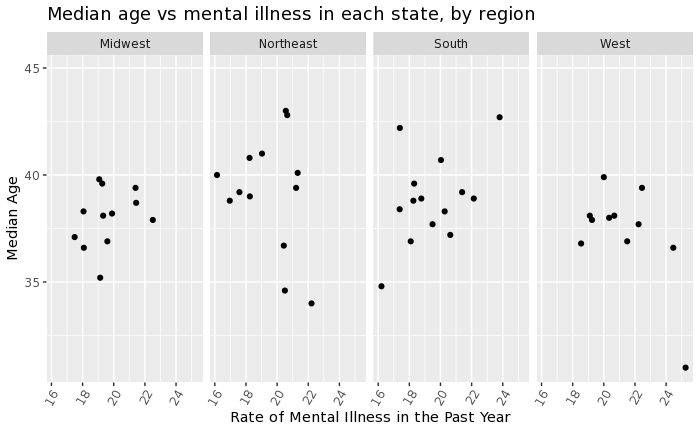

```r
ageDepression %>%
  ggplot(aes(x = totalDepression, y = medianAge)) + geom_point() + theme(axis.text.x = element_text(angle = 60, hjust=1)) + facet_grid(. ~ region) + ylab("Median Age") + xlab("Rate of Mental Illness in the Past Year") + ggtitle("Median age vs mental illness in each state, by region")
```

Lastly, I wanted to see which states are similar to each other, so I created a dendogram!

```r
stateDist <-
joinedDepression %>%
  select(Location, difference, totalDepression)
stateDiffs <- dist(stateDist)
```

```
NAs introduced by coercion
```

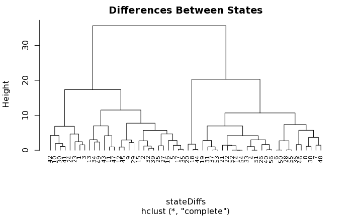

```r
hc <- hclust(stateDiffs)
plot(hc, labels = NULL, hang = -3,
     main = "Differences Between States", sub = NULL,
     xlab = NULL, ylab = "Height", cex = .7)
```

### Difficulties

The most difficult technical challenge was finding ways display my data. In the datasets I used, there was only one case in each state, so I was very limited in the graphics I could use. I overcame this by primarily using geom_point(), but I was able to add geom_smooth(), and I was also able to further display my data by using aesthetics (colors, shapes, etc).

## Conclusions

There were a few exciting findings in this project! * I learned that in Southern US, dogs are the primary pet, and in the Northeast, cats dominated.